# Clustering Analysis on ETF Trading

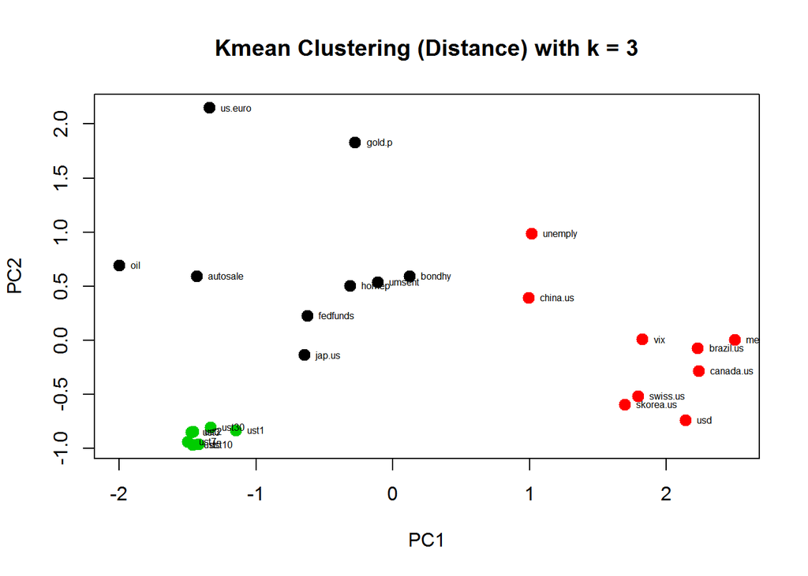

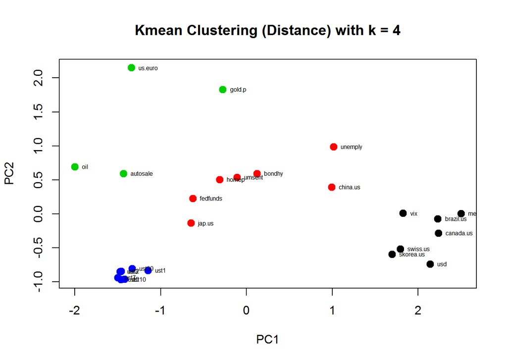

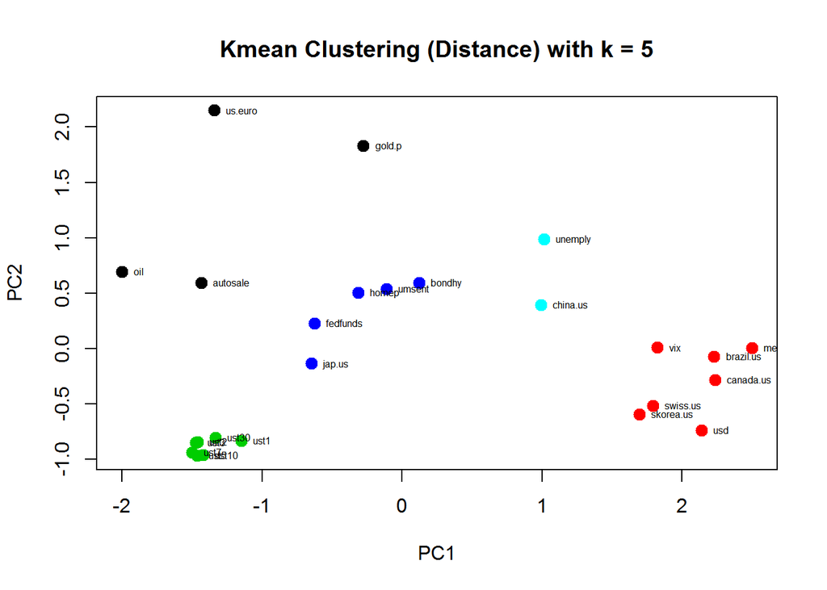

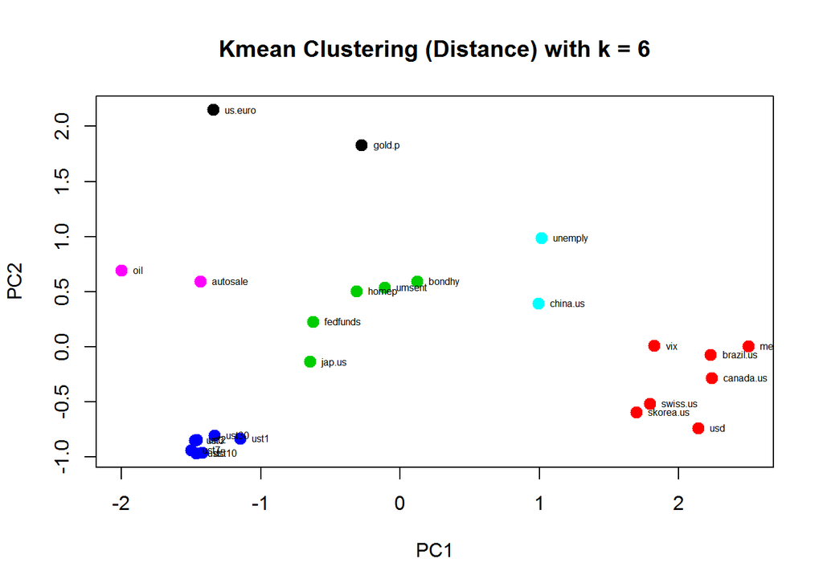

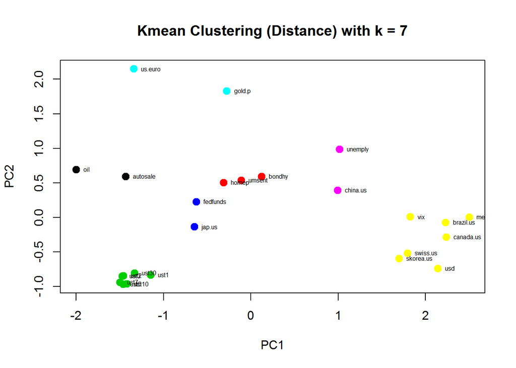

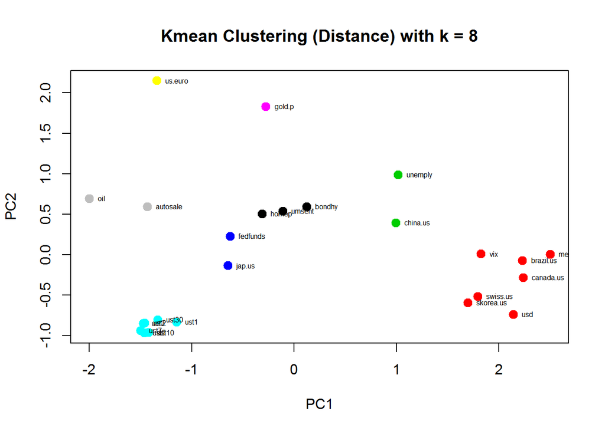

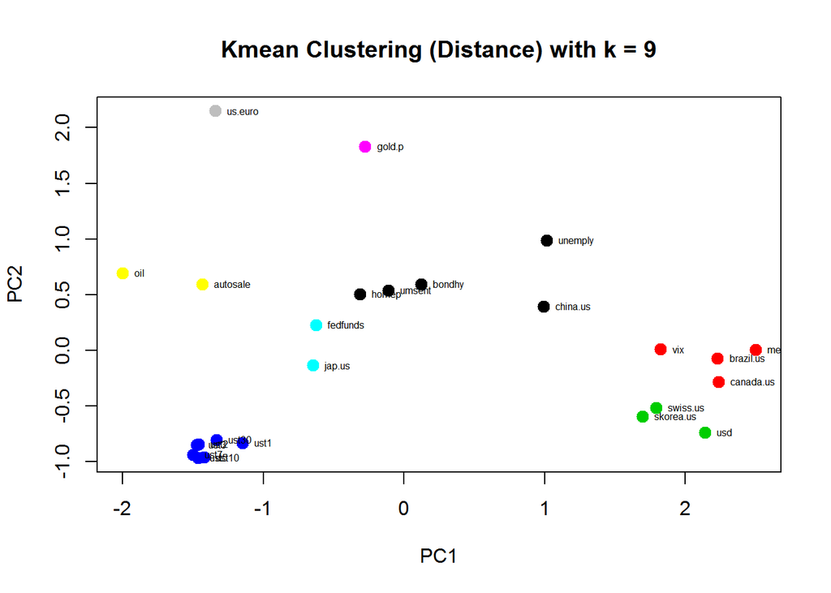

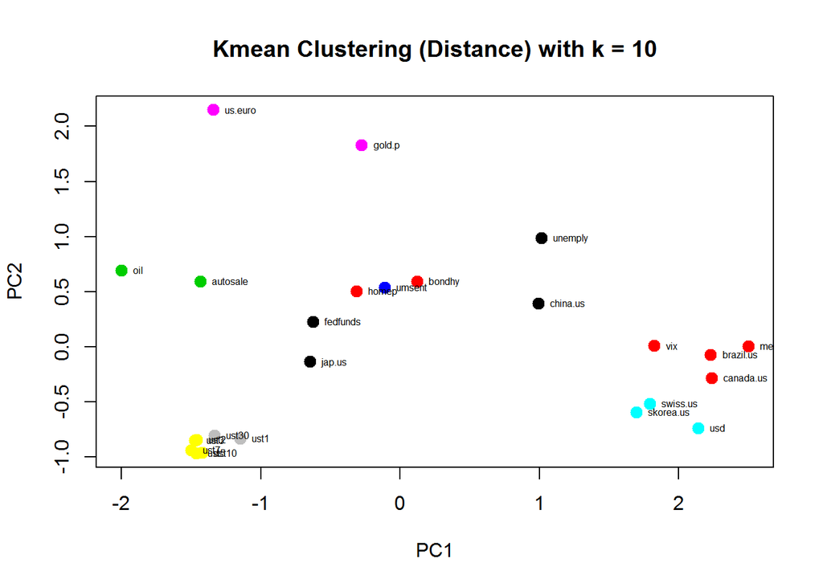

```r
test.kmeans(ret.c, 3, 10, add.labels = TRUE)
```

```r
# Selected Model (store cluster groups with their tags)
k = 8 ; k.out <- run.clustering(ret.c, k, "kmeans", max.elem.out = max.out, add.labels = TRUE)
```

[figure not shown]

```
## [1] Cluster 1 contents (up to 8) :usd skorea.us swiss.us
## [1] Cluster 2 contents (up to 8) :vix brazil.us canada.us mexico.us
## [1] Cluster 3 contents (up to 8) :china.us unemply
## [1] Cluster 4 contents (up to 8) :oil autosale
## [1] Cluster 5 contents (up to 8) :ust1 ust2 ust3 ust5 ust7 ust10 ust30
## [1] Cluster 6 contents (up to 8) :jap.us fedfunds
## [1] Cluster 7 contents (up to 8) :umsent homep bondhy
## [1] Cluster 8 contents (up to 8) :gold.p us.euro
```

```r
cluster.k.c <- k.out[[2]]
```

- (3.3): The next 2 tests are using the same kmeans and hierarcahcal clustering models as before but now we are analyzing the behaviors of the indicators by the distance between correlation coefficients of the data. The goal is to analyse a wider spectrum of possibilites for predictions and back testing. The PCA analysis looks better here and we test 3 - 10 clusters though the WSS plot did not offer us much clairty. Lower level clusters seemed to look good but the visualization analysis shows us that there are many variables spread out and more clusters will be need. Here is an example of how testng many models and creating a more automated procedure is a viable next step as these analysis techniues are open to interpretation. After much debate, we choose 8 clusters. The content analysis has changed but the grouoings are not bad and make sense under different scenarios of market conditions.

(3.4) Conduct Hierarchal Clustering (Corr. dist))

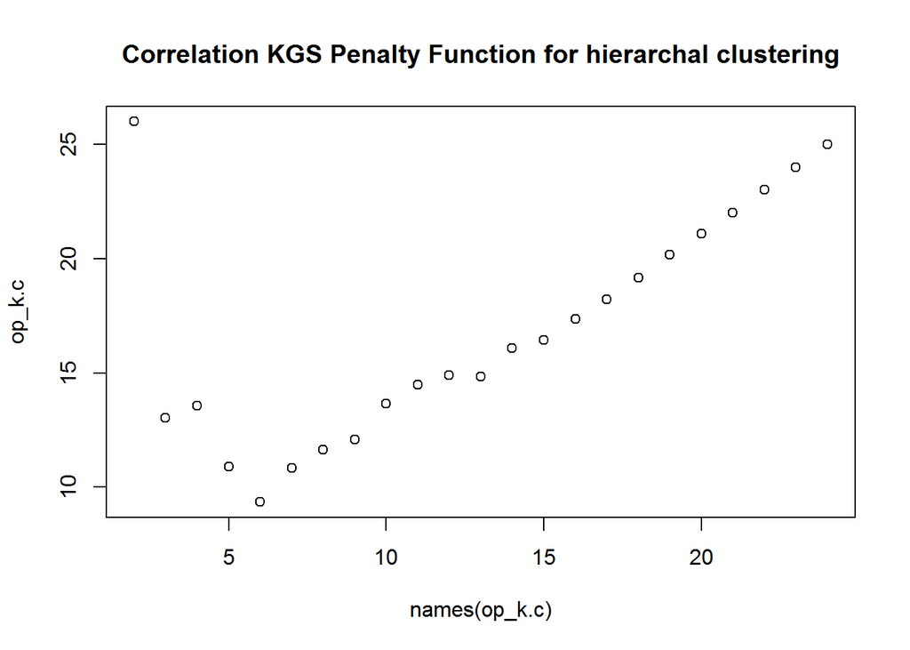

```r
set.seed(1234)

### Prepare Data Set for modelling (Create a disimilarity matrix of the variable correlations)
diss = 1 - abs(ret.c) # /corr/ becasue some correlations are negative
dist = as.dist(diss)

hc   = hclust(dist, method = "complete")

## Analyze Data to interpret possible clusterings
op_k.c <- kgs(hc, dist, maxclust = nrow(ret.c)-1) # Min = optimal clusters (k)
plot(names(op_k.c), op_k.c, main = "Correlation KGS Penalty Function for hierarchal clustering")
```